# Economic growth Notebook

We will use a dataset that was used in the paper: I just ran two million regressions by Sala-I-Martin and Model uncertainty in cross country growth regression by Fernandez et. al. The dataset has 41 possible explanatory variables with 72 countries. The data consists of 43 columns with the Country, y (economic growth in per capita GDP) and 41 possible predictor variables.

```r
eg <- read.csv("economicgrowth.csv")
str(eg)
```

```
'data.frame':   72 obs. of  43 variables:
 $ Country    : Factor w/ 72 levels "AR","AT","AU",..: 19 1 3 2 4 5 7 6 12 8 ...
 $ y          : num  0.01369 0.00642 0.0189 0.02922 0.02857 ...
 $ Abslat     : num  36.7 36.7 32.2 48.2 50.8 ...
 $ Spanish    : int  0 1 0 0 0 1 0 0 0 0 ...
 $ French     : int  1 0 0 0 0 0 0 0 1 0 ...
 $ Brit       : int  0 0 1 0 0 0 1 0 0 1 ...
 $ WarDummy   : int  0 1 0 0 0 0 0 0 0 0 ...
 $ LatAmerica : int  0 1 0 0 0 1 0 1 0 0 ...
 $ SubSahara  : int  0 0 0 0 0 0 1 0 1 0 ...
 $ OutwarOr   : int  1 0 0 0 1 0 0 0 1 1 ...
 $ Area       : int  2382 2767 7687 84 31 1099 582 8512 475 9976 ...
 $ PrScEnroll : num  0.46 0.98 1 1 1 0.64 0.42 0.95 0.65 1 ...
 $ LifeExp    : num  47.3 65.2 70.7 68.8 69.7 42.8 45.7 54.9 43.4 71.1 ...
 $ GDP60      : num  7.44 8.1 8.97 8.55 8.62 ...
```

[output cut: 29 more lines]

```r
eg1 <- subset(eg,select=-c(Country))
str(eg1)
```

```
'data.frame':   72 obs. of  42 variables:
 $ y          : num  0.01369 0.00642 0.0189 0.02922 0.02857 ...
 $ Abslat     : num  36.7 36.7 32.2 48.2 50.8 ...
 $ Spanish    : int  0 1 0 0 0 1 0 0 0 0 ...
 $ French     : int  1 0 0 0 0 0 0 0 1 0 ...
 $ Brit       : int  0 0 1 0 0 0 1 0 0 1 ...
 $ WarDummy   : int  0 1 0 0 0 0 0 0 0 0 ...
 $ LatAmerica : int  0 1 0 0 0 1 0 1 0 0 ...
 $ SubSahara  : int  0 0 0 0 0 0 1 0 1 0 ...
 $ OutwarOr   : int  1 0 0 0 1 0 0 0 1 1 ...
 $ Area       : int  2382 2767 7687 84 31 1099 582 8512 475 9976 ...
 $ PrScEnroll : num  0.46 0.98 1 1 1 0.64 0.42 0.95 0.65 1 ...
 $ LifeExp    : num  47.3 65.2 70.7 68.8 69.7 42.8 45.7 54.9 43.4 71.1 ...
 $ GDP60      : num  7.44 8.1 8.97 8.55 8.62 ...
 $ Mining     : num  0.196 0.023 0.038 0.004 0 0.075 0.533 0.017 0.088 0.034 ...
```

[output cut: 28 more lines]

We now do model selection by exhaustive search. Note that we have 2^41 which is approximately 2 trillion possible regressions to run. The leaps package has some smart ways to search over this space by avoiding visiting parts of the space where the optimum cannnot exist. It employs a branch and bound algorithm to search more efficiently. This would take a few minutes to run on a laptop. The model shows the bias-variance tradeoff. We can also plot the variables identified using the plot command.

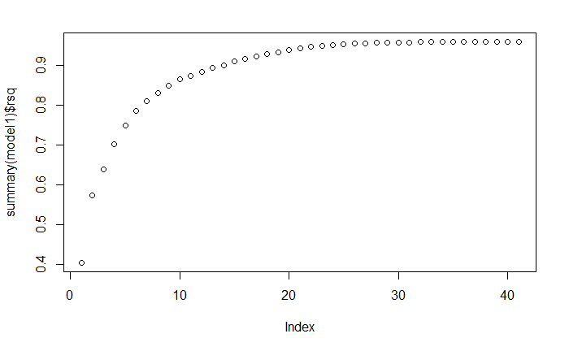

```r
library(leaps)
model1 <- regsubsets(y~.,data=eg1,nvmax=41)
plot(summary(model1)$rsq)
```

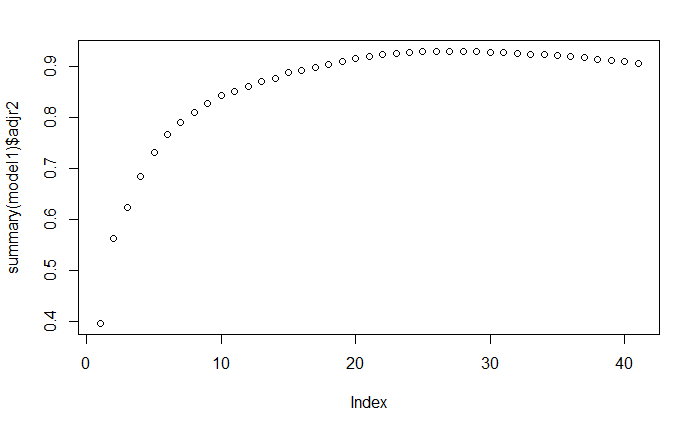

```r
plot(summary(model1)$adjr2)
```

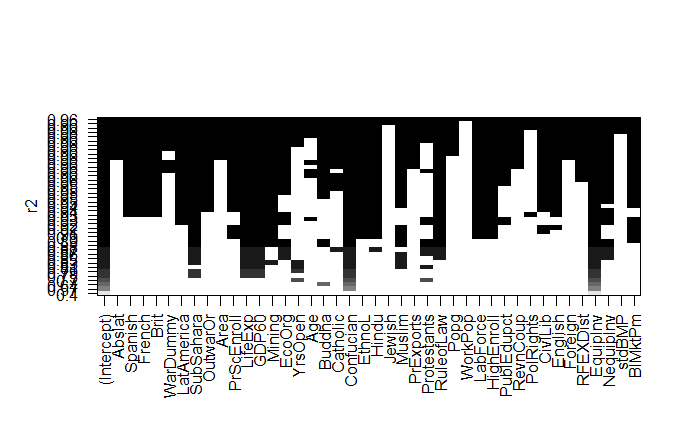

```r
plot(model1,scale=c("r2"))
```

We next use the forward stepwise selection method which runs much faster as should be expected. Note that the results are not identical to what we obtained with the exhaustive selection approach.

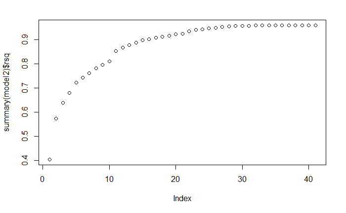

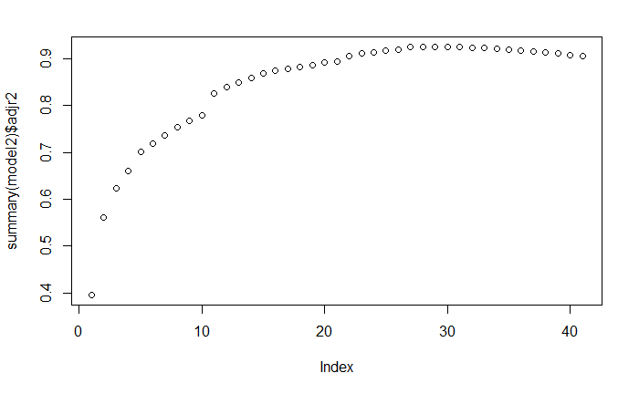

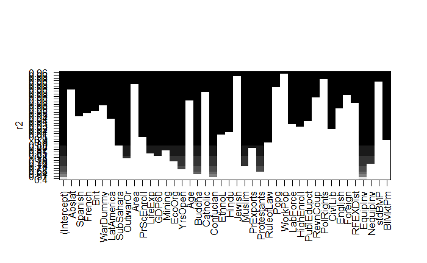

The results indicate that with model 1, we have 1) EquipInv, 2) Confucian, EquipInv, 3) Buddha, Confucian, EquipInv, 4) YrsOpen, Confucian, Protestants, EquipInv while for model 2, we have 1) EquipInv, 2) Confucian, EquipInv, 3) Buddha, Confucian, EquipInv, 4) Buddha, Protestants, EquipInv, Confucian and so on. The results are different from the two models.

```
   (Intercept) Abslat Spanish French  Brit WarDummy LatAmerica SubSahara OutwarOr  Area PrScEnroll
1         TRUE  FALSE   FALSE  FALSE FALSE    FALSE      FALSE     FALSE    FALSE FALSE      FALSE
2         TRUE  FALSE   FALSE  FALSE FALSE    FALSE      FALSE     FALSE    FALSE FALSE      FALSE
3         TRUE  FALSE   FALSE  FALSE FALSE    FALSE      FALSE     FALSE    FALSE FALSE      FALSE
4         TRUE  FALSE   FALSE  FALSE FALSE    FALSE      FALSE     FALSE    FALSE FALSE      FALSE
5         TRUE  FALSE   FALSE  FALSE FALSE    FALSE      FALSE      TRUE    FALSE FALSE      FALSE
6         TRUE  FALSE   FALSE  FALSE FALSE    FALSE      FALSE      TRUE    FALSE FALSE      FALSE
7         TRUE  FALSE   FALSE  FALSE FALSE    FALSE      FALSE     FALSE    FALSE FALSE      FALSE
8         TRUE  FALSE   FALSE  FALSE FALSE    FALSE      FALSE      TRUE    FALSE FALSE      FALSE
9         TRUE  FALSE   FALSE  FALSE FALSE    FALSE      FALSE      TRUE    FALSE FALSE      FALSE
10        TRUE  FALSE   FALSE  FALSE FALSE    FALSE      FALSE      TRUE    FALSE FALSE      FALSE
11        TRUE  FALSE   FALSE  FALSE FALSE    FALSE      FALSE      TRUE    FALSE FALSE      FALSE
12        TRUE  FALSE   FALSE  FALSE FALSE    FALSE      FALSE      TRUE    FALSE FALSE      FALSE
13        TRUE  FALSE   FALSE  FALSE FALSE    FALSE      FALSE      TRUE    FALSE FALSE      FALSE
14        TRUE  FALSE   FALSE  FALSE FALSE    FALSE      FALSE      TRUE    FALSE FALSE       TRUE
```

[output cut: 82 more lines]

```
   (Intercept) Abslat Spanish French  Brit WarDummy LatAmerica SubSahara OutwarOr  Area PrScEnroll
1         TRUE  FALSE   FALSE  FALSE FALSE    FALSE      FALSE     FALSE    FALSE FALSE      FALSE
2         TRUE  FALSE   FALSE  FALSE FALSE    FALSE      FALSE     FALSE    FALSE FALSE      FALSE
3         TRUE  FALSE   FALSE  FALSE FALSE    FALSE      FALSE     FALSE    FALSE FALSE      FALSE
4         TRUE  FALSE   FALSE  FALSE FALSE    FALSE      FALSE     FALSE    FALSE FALSE      FALSE
5         TRUE  FALSE   FALSE  FALSE FALSE    FALSE      FALSE     FALSE    FALSE FALSE      FALSE
6         TRUE  FALSE   FALSE  FALSE FALSE    FALSE      FALSE     FALSE    FALSE FALSE      FALSE
7         TRUE  FALSE   FALSE  FALSE FALSE    FALSE      FALSE     FALSE    FALSE FALSE      FALSE
8         TRUE  FALSE   FALSE  FALSE FALSE    FALSE      FALSE     FALSE    FALSE FALSE      FALSE
9         TRUE  FALSE   FALSE  FALSE FALSE    FALSE      FALSE     FALSE     TRUE FALSE      FALSE
10        TRUE  FALSE   FALSE  FALSE FALSE    FALSE      FALSE     FALSE     TRUE FALSE      FALSE
11        TRUE  FALSE   FALSE  FALSE FALSE    FALSE      FALSE     FALSE     TRUE FALSE      FALSE
12        TRUE  FALSE   FALSE  FALSE FALSE    FALSE      FALSE     FALSE     TRUE FALSE      FALSE
13        TRUE  FALSE   FALSE  FALSE FALSE    FALSE      FALSE     FALSE     TRUE FALSE      FALSE
14        TRUE  FALSE   FALSE  FALSE FALSE    FALSE      FALSE      TRUE     TRUE FALSE      FALSE
```

[output cut: 82 more lines]

LASSO model: The results indicate that for variables such as EquipInv, YrsOpen and Confucian for many values of lambda, these occur while some other variables such as Abslat do not show up as often. Such results help illustrate the reliabiltiy of possible predictors for economic growth and can also cast doubts on the robustness of the resutls for certain variables which might be proposed as being correlated with growth.

```r
library(glmnet)
x <- as.matrix(eg1[,c(2:42)])
model3 <- glmnet(x,eg1$y)
model3$df
```

```
 [1]  0  1  2  3  3  3  3  4  4  4  4  5  5  7  7  9 10 10 11 12 13 13 14 15 17 19 20 20 21 23 24 24 26 26 26 26 27 28 29 30 30 30 30 32 32
[46] 34 35 35 35 34 35 35 35 37 37 36 36 36 36 36 36 36 36 38 40 41 41 41 41 41 41 41 41 41 41 41 41 40 40 40 40 40 40 40 40 40
```

```r
model3$beta["EquipInv",]
```

```
        s0         s1         s2         s3         s4         s5         s6         s7         s8         s9        s10        s11
0.00000000 0.02989896 0.05202483 0.06760673 0.08042867 0.09212352 0.10277946 0.11258867 0.12154191 0.12971174 0.13715581 0.14406270
       s12        s13        s14        s15        s16        s17        s18        s19        s20        s21        s22        s23
0.15040049 0.15383321 0.15867593 0.16258346 0.16444915 0.16555791 0.16661977 0.16734255 0.16832148 0.16948025 0.17126770 0.17293008
       s24        s25        s26        s27        s28        s29        s30        s31        s32        s33        s34        s35
0.17351524 0.17220683 0.16702669 0.16130824 0.15651196 0.15187566 0.14705527 0.14234527 0.13738774 0.13193100 0.12706968 0.12274067
       s36        s37        s38        s39        s40        s41        s42        s43        s44        s45        s46        s47
0.11929709 0.11510558 0.11298039 0.11149575 0.11069796 0.10979416 0.10902316 0.10822285 0.10826583 0.10805193 0.10978025 0.11122019
       s48        s49        s50        s51        s52        s53        s54        s55        s56        s57        s58        s59
0.11265440 0.11364832 0.11454541 0.11517577 0.11571790 0.11637044 0.11769020 0.11837771 0.11911269 0.11981383 0.12046601 0.12107996
       s60        s61        s62        s63        s64        s65        s66        s67        s68        s69        s70        s71
0.12163600 0.12214121 0.12259898 0.12310262 0.12363149 0.12418720 0.12446285 0.12470910 0.12491215 0.12509626 0.12525557 0.12540204
       s72        s73        s74        s75        s76        s77        s78        s79        s80        s81        s82        s83
0.12553559 0.12566579 0.12577917 0.12588798 0.12597718 0.12607745 0.12615294 0.12619169 0.12622857 0.12626553 0.12629465 0.12632607
       s84        s85
0.12635177 0.12637656
```

```r
model3$beta["YrsOpen",]
```

```
           s0            s1            s2            s3            s4            s5            s6            s7            s8            s9
 0.000000e+00  0.000000e+00  8.411755e-04  2.348983e-03  3.459478e-03  4.469387e-03  5.389575e-03  6.018196e-03  6.519700e-03  6.974666e-03
          s10           s11           s12           s13           s14           s15           s16           s17           s18           s19
 7.389210e-03  7.501796e-03  7.459716e-03  7.359030e-03  7.580682e-03  7.776759e-03  7.780396e-03  7.624393e-03  7.531362e-03  7.530964e-03
          s20           s21           s22           s23           s24           s25           s26           s27           s28           s29
 7.433922e-03  7.333904e-03  7.238579e-03  7.105824e-03  7.186242e-03  6.986698e-03  6.950097e-03  7.060531e-03  7.172980e-03  7.283439e-03
          s30           s31           s32           s33           s34           s35           s36           s37           s38           s39
 7.355836e-03  7.181306e-03  7.000231e-03  6.575529e-03  6.222930e-03  5.895569e-03  5.633759e-03  5.344985e-03  4.899859e-03  4.378597e-03
          s40           s41           s42           s43           s44           s45           s46           s47           s48           s49
 3.952915e-03  3.557960e-03  3.207090e-03  2.878671e-03  2.436668e-03  1.985109e-03  1.678964e-03  1.473317e-03  1.286642e-03  1.069770e-03
          s50           s51           s52           s53           s54           s55           s56           s57           s58           s59
 8.549662e-04  6.260712e-04  4.303385e-04  2.377157e-04  3.966491e-05  0.000000e+00  0.000000e+00  0.000000e+00  0.000000e+00  0.000000e+00
          s60           s61           s62           s63           s64           s65           s66           s67           s68           s69
 0.000000e+00  0.000000e+00  0.000000e+00  0.000000e+00 -3.471530e-05 -2.031494e-04 -4.074152e-04 -5.981505e-04 -7.729290e-04 -9.349521e-04
          s70           s71           s72           s73           s74           s75           s76           s77           s78           s79
-1.081157e-03 -1.216336e-03 -1.332769e-03 -1.445648e-03 -1.548900e-03 -1.638620e-03 -1.721495e-03 -1.802933e-03 -1.871868e-03 -1.934607e-03
          s80           s81           s82           s83           s84           s85
-1.986890e-03 -2.049210e-03 -2.087723e-03 -2.138088e-03 -2.175417e-03 -2.212684e-03
```

```r
model3$beta["Confucian",]
```

```
          s0           s1           s2           s3           s4           s5           s6           s7           s8           s9
0.0000000000 0.0000000000 0.0000000000 0.0001621431 0.0073470601 0.0138931647 0.0198577304 0.0247184313 0.0289443053 0.0327943465
         s10          s11          s12          s13          s14          s15          s16          s17          s18          s19
0.0363023597 0.0394825701 0.0423720755 0.0451703608 0.0473677815 0.0494006357 0.0513695192 0.0532800898 0.0550396318 0.0568168456
         s20          s21          s22          s23          s24          s25          s26          s27          s28          s29
0.0580045782 0.0590249207 0.0597445690 0.0602435836 0.0602429141 0.0596761196 0.0592215257 0.0587600550 0.0583418572 0.0577364260
         s30          s31          s32          s33          s34          s35          s36          s37          s38          s39
0.0568774528 0.0562989043 0.0556491892 0.0554179214 0.0552196992 0.0550505400 0.0547964120 0.0546579435 0.0549502195 0.0555138745
         s40          s41          s42          s43          s44          s45          s46          s47          s48          s49
0.0567310638 0.0577869720 0.0587342490 0.0595534109 0.0601290032 0.0605148323 0.0613936418 0.0624443098 0.0635110808 0.0642446690
         s50          s51          s52          s53          s54          s55          s56          s57          s58          s59
0.0649079907 0.0654469803 0.0659337479 0.0663722431 0.0666905089 0.0669304933 0.0671519438 0.0673599910 0.0675530982 0.0677332176
         s60          s61          s62          s63          s64          s65          s66          s67          s68          s69
0.0678979832 0.0680485327 0.0681856232 0.0684322068 0.0688534260 0.0693838201 0.0698945900 0.0703152378 0.0706821885 0.0710215911
         s70          s71          s72          s73          s74          s75          s76          s77          s78          s79
0.0713174773 0.0715927904 0.0718321509 0.0720705210 0.0722813913 0.0724716965 0.0726395166 0.0728104598 0.0729514088 0.0730629130
         s80          s81          s82          s83          s84          s85
0.0731568200 0.0732688430 0.0733399001 0.0734313972 0.0735005287 0.0735691984
```

```r
model3$beta["Abslat",]
```

```
           s0            s1            s2            s3            s4            s5            s6            s7            s8            s9
 0.000000e+00  0.000000e+00  0.000000e+00  0.000000e+00  0.000000e+00  0.000000e+00  0.000000e+00  0.000000e+00  0.000000e+00  0.000000e+00
          s10           s11           s12           s13           s14           s15           s16           s17           s18           s19
 0.000000e+00  0.000000e+00  0.000000e+00  0.000000e+00  0.000000e+00  0.000000e+00  0.000000e+00  0.000000e+00  0.000000e+00  0.000000e+00
          s20           s21           s22           s23           s24           s25           s26           s27           s28           s29
 0.000000e+00  0.000000e+00  0.000000e+00  0.000000e+00  0.000000e+00  0.000000e+00  0.000000e+00  0.000000e+00  0.000000e+00  0.000000e+00
          s30           s31           s32           s33           s34           s35           s36           s37           s38           s39
 0.000000e+00  0.000000e+00  0.000000e+00  0.000000e+00  0.000000e+00  0.000000e+00  0.000000e+00  0.000000e+00  0.000000e+00  0.000000e+00
          s40           s41           s42           s43           s44           s45           s46           s47           s48           s49
 0.000000e+00  0.000000e+00  0.000000e+00  0.000000e+00  0.000000e+00  0.000000e+00  0.000000e+00  0.000000e+00  0.000000e+00  0.000000e+00
          s50           s51           s52           s53           s54           s55           s56           s57           s58           s59
 0.000000e+00  0.000000e+00  0.000000e+00  0.000000e+00  0.000000e+00  0.000000e+00  0.000000e+00  0.000000e+00  0.000000e+00  0.000000e+00
          s60           s61           s62           s63           s64           s65           s66           s67           s68           s69
 0.000000e+00  0.000000e+00  0.000000e+00  0.000000e+00 -1.622437e-06 -7.518398e-06 -1.431802e-05 -2.042576e-05 -2.591297e-05 -3.102535e-05
          s70           s71           s72           s73           s74           s75           s76           s77           s78           s79
-3.556897e-05 -3.979984e-05 -4.337126e-05 -4.690859e-05 -5.016168e-05 -5.296114e-05 -5.555386e-05 -5.806661e-05 -6.007978e-05 -6.195865e-05
          s80           s81           s82           s83           s84           s85
-6.347919e-05 -6.536241e-05 -6.648517e-05 -6.799466e-05 -6.910986e-05 -7.022663e-05
```

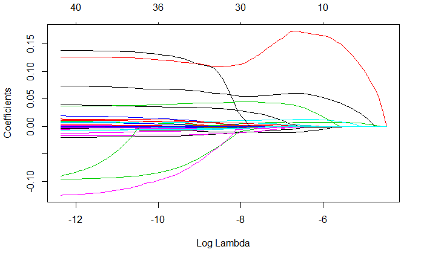

```r
plot(model3,xvar="lambda")
```